# Rendimiento del Partido del Presidente de Turno y Tasa de Desempleo en Estados Unidos de America (1899-2019)

Author

27600050

## Rendimiento del Partido del Presidente de Turno y Tasa de Desempleo en Estados Unidos de America (1899-2019)

En este análisis de datos se realizara un estudio del rendimiento o desempeño del partido del presidente de turno durante su mandato, para buscar posibles relaciones con la tasa de desempleo estadounidense y determinar si la presencia de un presidente democrata o republicano y escaños en la cámara de representantes favorece o no al empleo.

## 1. Cargar librerias e importación de datos

Para la realización de la presente análisis de datos se utilizaron las librerias tidyverse, ggplot2, openintro, DT, gt, dplyr y lmtest.

1.1 Importar datos

Se utiliza la librería openintro, y el codigo data() para descargar los datos ‘midterms_house’, de Openintro: https://www.openintro.org/data/index.php?data=midterms_house , y renombrar variables del conjunto de datos al español.

## **2. Valores Estadísticos y Tablas Resúmenes:**

**2.1 TABLA INTERACTIVA**

|  | año | presidente | partido | tasa_de_desempleo | camara_de_representantes |
| --- | --- | --- | --- | --- | --- |
| 1 | 1899 | William McKinley | Republican | 11.62 | -9.22330097087377 |
| 2 | 1903 | Theodore Roosevelt | Republican | 4.3 | -4.27590673575129 |
| 3 | 1907 | Theodore Roosevelt | Republican | 3.29 | -12.2914989657737 |
| 4 | 1911 | William Howard Taft | Republican | 5.86 | -26.5906404283429 |
| 5 | 1915 | Woodrow Wilson | Democrat | 6.63 | -20.9621993127148 |
| 6 | 1919 | Woodrow Wilson | Democrat | 3.38 | -10.2803738317757 |
| 7 | 1923 | Calvin Coolidge | Republican | 6.93 | -25.4966887417219 |
| 8 | 1927 | Calvin Coolidge | Republican | 4.02 | -3.64372469635626 |
| 9 | 1931 | Herbert Clark Hoover | Republican | 8.94 | -19.2592592592593 |
| 10 | 1935 | Franklin Delano Roosevelt | Democrat | 21.3 | 2.87539936102235 |

[output cut: 21 more lines]

**2. TABLAS ESTADÍSTICAS**

Los Republicanos han sido los que han ocupado la presidencia durante mayor número de periodos, con 17 veces, mientras que los demócratas, 14.

**Mandatos: Demócratas vs Republicanos:**

```
  Democrat Republican
        14         17
```

Las tasa de desempleo minima fue de 3.29%, en el 1907 con el Republicano Theodore Rooselvelt en la presidencia, a su vez el máximo se ubicó en 1935, con un valor de 21.3%, bajo la presidencia del demócrata Franklin Delano Roosevelt, en el período de la Gran Recesión. La tasa promedio de desempleo en Estados Unidos, para el período de 1899 al 2019, fue de 6.731%, y la mediana de 5.6%.

**Valores estadisticos de la tasa de desempleo**

```
   Min. 1st Qu.  Median    Mean 3rd Qu.    Max.
  3.290   4.550   5.600   6.731   6.865  21.300
```

**Número de mandatos por presidente**

Los presidentes que han ejercido durante mas de un mandato son los siguientes: Franklin Delano Roosevelt, con tres mandatos, y con dos: Barack Obama, Calvin Coolidge, Dwight Eisenhower, Lyndon Baines Johnson, Ronald Reagan, Woodrow Wilson, Theodore Roosevelt, Harry Truman, George Bush y Bill Clinton.

**Mandatos por presidente:**

```
              Barack Obama               Bill Clinton
                         2                          2
           Calvin Coolidge               Donald Trump
                         2                          1
   Dwight David Eisenhower  Franklin Delano Roosevelt
                         2                          3
George Herbert Walker Bush         George Walker Bush
                         1                          2
       Gerald Rudolph Ford            Harry S. Truman
                         1                          2
      Herbert Clark Hoover               Jimmy Carter
                         1                          1
     Lyndon Baines Johnson      Richard Milhous Nixon
                         2                          1
      Ronald Wilson Reagan         Theodore Roosevelt
                         2                          2
       William Howard Taft           William McKinley
                         1                          1
            Woodrow Wilson
                         2
```

### **3. Análisis Exploratorio de los Datos (EDA)**

**HISTOGRAMA**

Las tasas de desempleo en Estados Unidos han tenido una mayor frecuencia en los valores cercanos al 5%

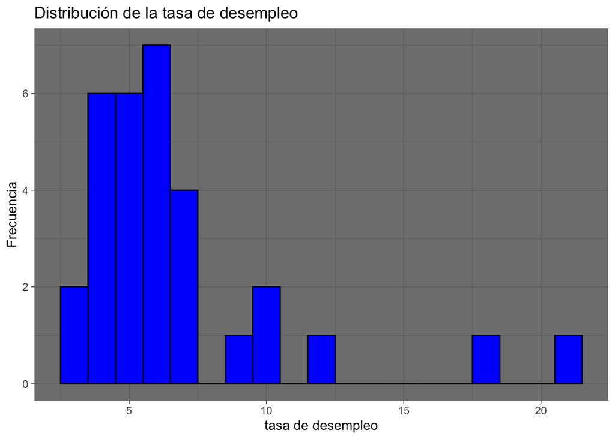

**BOXPLOT**

Entre 1899 - 2019, solo han habido tres periodos con valores por encima del 10% de tasa de desempleo, para los años 1935, 1939, presidente Franklin Delano Roosevelt (Demócrata), y 1899 con William McKinley (Republicano).

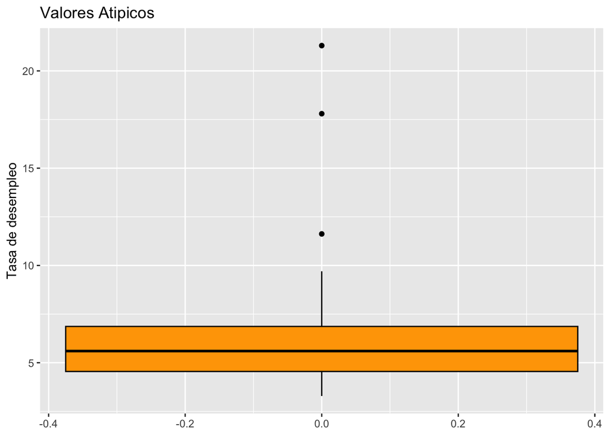

**DIAGRAMA DE DISPERSIÓN:**

Desempleo durante mandato de presidente republicano y puestos ganados o perdidos por la cámara de representantes del partido republicano, en el mandato.

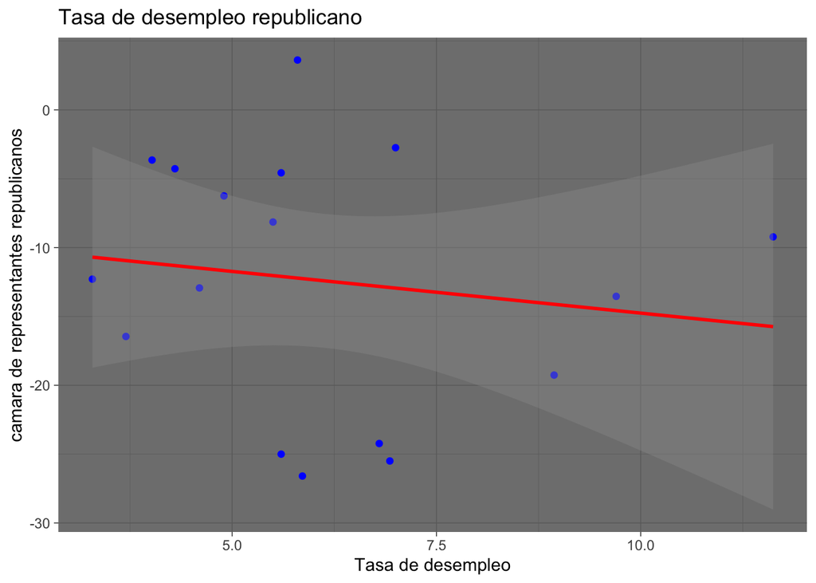

A medida que la tasa de desempleo aumenta, los republicanos tienden a perder mas puestos en la cámara de representantes, bajo la presidencia de un presidente republicano.

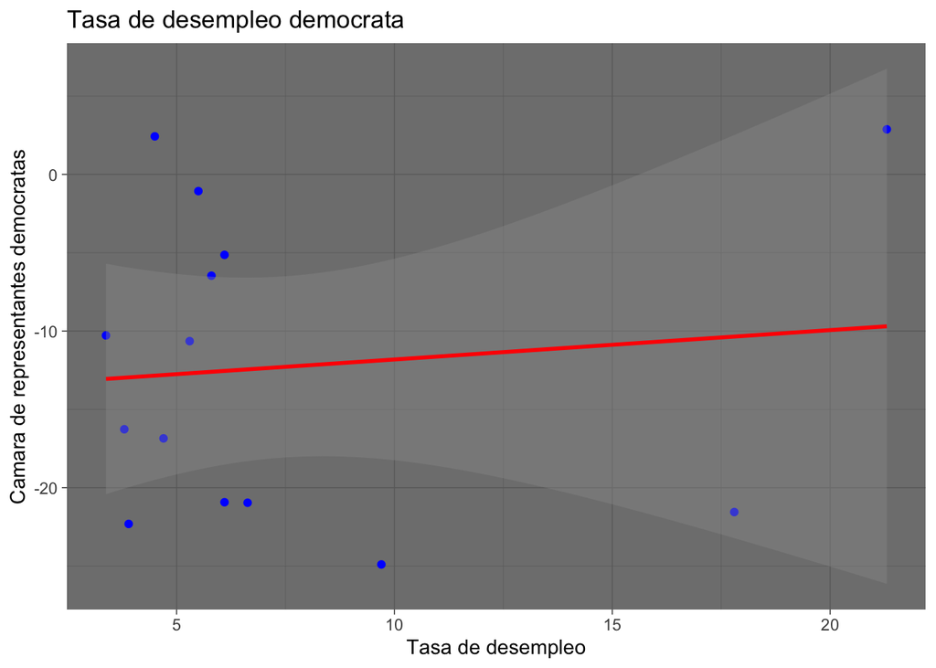

A medida que la tasa de desempleo aumenta, los demócratas tienden a aumentar mas puestos en la cámara de representantes, bajo la presidencia de un presidente demócrata.

**COMPARACIÓN DE TASA DE DESEMPLEOS:**

**Promedio de la tasa de desempleo bajo el mandato de presidentes democratas:**

```
[1] 7.465
```

**Promedio de la tasa de desempleo bajo el mandato de presidentes republicanos:**

```
[1] 6.127059
```

*El nivel de empleo estadounidense, en promedio, ha sido mejor bajo la presidencia de republicanos, con una tasa de desempleo promedio de 6,12%, en contraste al 7,46% de los democratas.*

**TASA DE DESEMPLEO, Demócratas vs Republicanos**

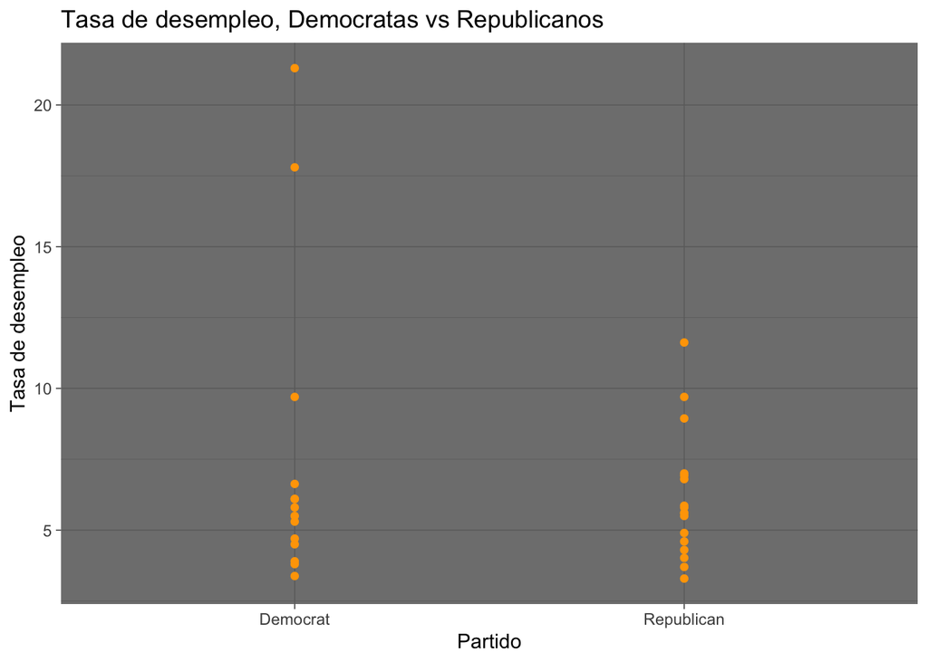

**Evolución de la tasa de desempleo, EEUU 1899-2019**

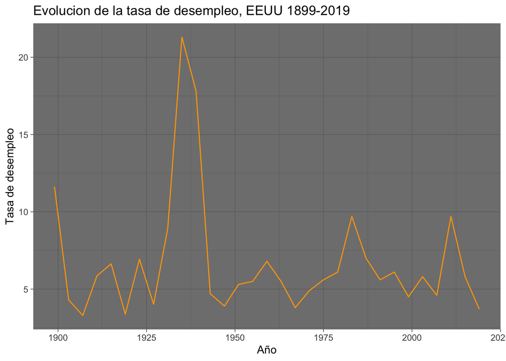

Los períodos donde la tasa de desempleo ha tenido valores por encima de la media, estan ubicados en fechas donde hubo un deterioro de la economía estadounidense:

1899: Depresión de finales del siglo XIX, iniciada en 1893.

1930 - 1939: La gran depresión global de la década de los 30, originada por la caída de los mercados financieros en Estados Unidos

2008: Crisis hipotecaria que inició en Estados Unidos y tuvo impacto a nivel global.

**REGRESIONES LINEALES Y PRUEBAS DE CAUSALIDAD DE GRANGER:**

**Regresión lineal: Tasa de desempleo (variable dependiente), cambios en la cámara de representantes (independiente)**

```
Call:
lm(formula = tasa_de_desempleo ~ camara_de_representantes, data = desempleo)

Coefficients:
             (Intercept)  camara_de_representantes
                6.847949                  0.009439
```

La regresión lineal muestra con un coeficiente de 0.0094, que ante una unidad de incremento en la cámara de representantes, tanto de Republicanos como Democrata, tiene un impacto positivo mínimo en la tasa de desempleo de EEUU.

**Regresión lineal: Cambios en la cámara de representantes (dependiente), tasa de desempleo (variable independiente):**

```
Call:
lm(formula = camara_de_representantes ~ tasa_de_desempleo, data = desempleo)

Coefficients:
      (Intercept)  tasa_de_desempleo
        -12.70284            0.05112
```

Mostrando que ante aumentos unitarios en la tasa de desempleo de EEUU, la cámara de representantes del presidente de turno aumenta en 0.051.

**PRUEBAS DE CAUSALIDAD DE GRANGER**

Para determinar si el cambio de una variable origina o provoca un cambio en la otra, y si las variables son buenas predictoras entres sí, se utilizo el código para realizar la prueba de causalidad de Granger, del paquete “lmtest”, https://www.statology.org/granger-causality-test-in-r/ .

**Prueba: ¿Tasa de desempleo genera cambios en la cámara de representantes?**

```
Granger causality test

Model 1: desempleo$camara_de_representantes ~ Lags(desempleo$camara_de_representantes, 1:2) + Lags(desempleo$tasa_de_desempleo, 1:2)
Model 2: desempleo$camara_de_representantes ~ Lags(desempleo$camara_de_representantes, 1:2)
  Res.Df Df     F Pr(>F)
1     24
2     26 -2 0.693 0.5098
```

*Con un pvalue > 0.05 , de 0.50, la tasa de desempleo no genera cambios en la camara de representantes, lo contrario al resultado de la regresion lineal anterior.*

**Prueba: ¿Cambios en la cámara de representantes genera variaciones en la tasa de desempleo?**

```
Granger causality test

Model 1: desempleo$tasa_de_desempleo ~ Lags(desempleo$tasa_de_desempleo, 1:2) + Lags(desempleo$camara_de_representantes, 1:2)
Model 2: desempleo$tasa_de_desempleo ~ Lags(desempleo$tasa_de_desempleo, 1:2)
  Res.Df Df      F Pr(>F)
1     24
2     26 -2 0.4676 0.6321
```

*Con un pvalue > 0.05 , de 0.63, cambios en la cámara de representantes no generan variaciones en la tasa de desempleo, en contraposición al resultado de la regresion lineal. Tanto la tasa de desempleo y cambios en la cámara de representantes, no son buenas predictoras de cambios sobre ellas, el cambio previo de una no afecta a la otra.*

Con estos resultados se puede llegar a la conclusión parcial de que cambios en los escaños de la cámara de representantes del partido del presidente de turno en los Estados Unidos de America, no generan cambios y relaciones causales significativas con la tasa de desempleo.

#### 4. Aplicación de mutates (Derivación o Agregación de Datos)

**Mutates**

Creación de una nueva variable, para medir el cambio en la cámara de representantes en el partido del presidente de turno, ante cambios en la tasa de desempleo de EEUU

|  | año | cambios_por_tasa_desempleo | presidente | partido |
| --- | --- | --- | --- | --- |
| 1 | 1899 | -0.7937436291629751 | William McKinley | Republican |
| 2 | 1903 | -0.9943969152909977 | Theodore Roosevelt | Republican |
| 3 | 1907 | -3.736017922727568 | Theodore Roosevelt | Republican |
| 4 | 1911 | -4.537651950229164 | William Howard Taft | Republican |
| 5 | 1915 | -3.161719353350649 | Woodrow Wilson | Democrat |
| 6 | 1919 | -3.041530719460266 | Woodrow Wilson | Democrat |
| 7 | 1923 | -3.679175864606335 | Calvin Coolidge | Republican |
| 8 | 1927 | -0.9063991781980747 | Calvin Coolidge | Republican |
| 9 | 1931 | -2.154279559201264 | Herbert Clark Hoover | Republican |
| 10 | 1935 | 0.1349952751653686 | Franklin Delano Roosevelt | Democrat |

[output cut: 21 more lines]

Como se puede apreciar en la Tabla de Datos, los cinco presidentes que perdieron más representantes de su partido durante su mandato ante cambios en la tasa de desempleo, han sido Truman, Howard, Rudolph Ford, Donald Trump y Baines Johnson. Por otro lado, los únicos tres presidentes en donde creció la camara de representantes de su partido, fueron George Bush, Bill Clinton y Franklin Delano Rooselvelt

##### **Referencias:**

https://ggplot2.tidyverse.org/reference/geom_smooth.html

https://www.sthda.com/english/wiki/ggplot2-scatter-plots-quick-start-guide-r-software-and-data-visualization

https://eh.net/encyclopedia/the-depression-of-1893/

https://www.datacamp.com/tutorial/linear-regression-R

https://eh.net/encyclopedia/the-depression-of-1893/